# The Finale

Jordan and Kristen’s project

Predictive analysis using reduced dimensionality

Kristen Beamer , Jordan Peeples  
4-29-2021

In this post we will combine much of our past work to understand our data in order to perform predictive analysis using a reduced dimension form of the HSLS:09 data. To get our reduced dimension data frame, we will first divide our data into sub-categories, then perform imputation and MCA (multiple correspondence analysis, discussed in the previous blog post), and finally combine the reduced dimension subcategories into a smaller data frame. After this work, we will use learners to perform predictive analysis.

### Subcategorization

The first step here is to divide the categorical variables within the different surveys into smaller categories. This step required heavy use of the data dictionary and an understanding of which variables were related. We first perform the subdivision for the students survey. Below you can see that we split the student survey variables into those about credits, background, extracurricular activities, math, science, etc.

```r
###students
#first, only include qualitative variables
studentDataStudentsMCA <- studentDataStudents %>% select_if(is.factor)

#divide the student data into more general categories
studentCredits <- studentDataStudentsMCA %>% select(X3T1CREDALG1:X3TNEWBASIC)
studentBackground <- studentDataStudentsMCA %>% select(S1SEX:S1SCH0809)
studentExtracurricular <- studentDataStudentsMCA %>% select(S1MCLUB:S1SMUSEUM)
studentMath <- studentDataStudentsMCA %>% select(S1M8, S1M8GRADE, S1MPERSON1:S1MTCHEASY)
studentScience <- studentDataStudentsMCA %>% select(S1S8, S1S8GRADE, S1SPERSON1:S1STCHEASY)
studentThoughts <- studentDataStudentsMCA %>% select(S1SAFE:S1WORKING)
studentTalks <- studentDataStudentsMCA %>% select(S1MOMTALKM:S1NOTALKPRB)
studentPeers <- studentDataStudentsMCA %>% select(S1FRNDGRADES:S1SCICOMP)
studentTime <- studentDataStudentsMCA %>% select(S1HRMHOMEWK:S1HRONLINE)
studentMathScienceExp <- studentDataStudentsMCA %>% select(S1MYRS:S1IBSCI)
studentPlanning <- studentDataStudentsMCA %>% select(S1PLAN:S1IBTEST)
studentFuturePlans <- studentDataStudentsMCA %>% select(S1SUREHSGRAD:S1TALKFUTURE)

#separately define a group for numeric GPA variables
studentGPA <- studentData %>% select(X3TGPAENG, X3TGPAMAT, X3TGPAHIMTH, X3TGPASCI, X3TGPAHISCI, X3TGPASOCST,
                                     X3TGPALANG, X3TGPAACAD, X3TGPACTE, X3TGPANONA,
                                     X3TGPASTEM, X3TGPATOT, X3TGPAWGT)
```

Next we subdivide the parents survey. Again we select variables that are similar through the data dictionary and our own familiarity with the features. Some of the categories are parent’s background, language, human capital, etc.

```r
###parents
# Select Categorical variables
studentDataParentsMCA <- studentDataParents %>% select_if(is.factor)
# Create categorical groups
parentBackground <- studentDataParentsMCA %>% select(P1RELSHP:P1USBORN2)
parentLanguage <- studentDataParentsMCA %>% select(P1HOMELANG:P1ELLEVER)
parentHumanCapital <- studentDataParentsMCA %>% select(P1HIDEG1:P1JOBONET2_STEM1)
parentIncome <- studentDataParentsMCA %>% select(P1INCOMECAT:P1OWNHOME)
parentChildMentalHealth <- studentDataParentsMCA %>% select(P1SLD:P1FRIEND)
parentChildBehavior <- studentDataParentsMCA %>% select(P1DROPOUT:P1PERFORM)
parentInvolvement <- studentDataParentsMCA %>% select(P1PTOMTG:P1ENGHWEFF)
parentComparison <- studentDataParentsMCA %>% select(P1MTHCOMP:P1ENGCOMP)
parentExtracurricular <- studentDataParentsMCA %>% select(P1ARTS:P1NOACT)
parentExpectations <- studentDataParentsMCA %>% select(P1EDUASPIRE:P1START)
parentCollegeSavings <- studentDataParentsMCA %>% select(P1HELPPAY:P1PREPPAY)
```

Now we consider the teacher survey. The survey asks teachers questions about their preferred methods of teaching and what they think about other math teachers. Therefore, we are able to combine related questions such as beliefs about school policies, gender beliefs, teaching methods, etc.

```r
###Teachers
# Only include qualitative variables
studentDataTeacherMCA <- studentDataTeacher %>% select_if(is.factor)

teacherEducationMath <- studentDataTeacherMCA %>% select(M1HIDEG:M1CERT912)
teacherBeliefsMath <- studentDataTeacherMCA %>% select(M1TEACHING:M1WORKHARD)
#keep M1ACHIEVE in mind
teacherMethodsMath <- studentDataTeacherMCA %>% select(M1GROUP:M1TEST)
teacherPolicyBeliefsMath <- studentDataTeacherMCA %>% select(M1ADVSENIOR:M1CHAIR)
teacherGenderBeliefsMath <- studentDataTeacherMCA %>% select(M1ENGCOMP:M1SCICOMP)
teacherProblemsMath <- studentDataTeacherMCA %>% select(M1TARDY:M1PARENT)
teacherSelfMath <- studentDataTeacherMCA %>% select(M1RETAIN:M1HOMEFX)
teacherGeneralMath <- studentDataTeacherMCA %>% select(M1PRESSURES:M1TFAIL)

teacherEducationSci <- studentDataTeacherMCA %>% select(N1HIDEG:N1HIMAJ_STEM, N1BACONT:N1CERTERT912)
teacherBeliefsSci <- studentDataTeacherMCA %>% select(N1TEACHING:N1WORKHARD)
#keep M1ACHIEVE in mind
teacherMethodsSci <- studentDataTeacherMCA %>% select(N1GROUP:N1TEST)
teacherPolicyBeliefsSci <- studentDataTeacherMCA %>% select(N1ADVSENIOR:N1CHAIR )
teacherGenderBeliefsSci <- studentDataTeacherMCA %>% select(N1ENGCOMP:N1SCICOMP)
teacherProblemsSci <- studentDataTeacherMCA %>% select(N1TARDY:N1PARENT)
teacherSelfSci <- studentDataTeacherMCA %>% select(N1RETAIN:N1HOMEFX)
teacherGeneralSci <- studentDataTeacherMCA %>% select(N1PRESSURES:N1TFAIL)
```

We repeat the sub-categorization for the administrator survey. Sub-categories of interest include: math and science programming, programs for struggling 9th graders, programs for 9th graders needing assistance, principal characteristics, and other programming (remedial, AP, IB, etc).

```r
#first, only include qualitative variables
studentDataAdminMCA <- studentDataAdmin %>% select_if(is.factor)
#Divide Admin Data into more general categories
AdminMathScienceProgramming <-studentDataAdminMCA %>% select(A1MTHSCIFAIR:A1MSNONE, A1ALG1LEVELS)
Admin9thGradeStruggling <- studentDataAdminMCA %>% select(A1G9SUMMER:A1G9OTHRPROG)
Admin9thGradeAssistance <- studentDataAdminMCA %>% select(A1G9ABSENTEE:A1G9OTHER)
AdminProgramming <- studentDataAdminMCA  %>% select(A1OFFERDOPRV:A1OFFERNONE)
AdminPrincipalMajor <- studentDataAdminMCA %>% select(A1HIMAJ_STEM:A1BAMAJ_STEM)
AdminSchoolProblems <- studentDataAdminMCA %>% select(A1TARDY:A1RESOURCES)
AdminCharacteristics<- studentDataAdminMCA %>% select(A1SCHCONTROL, A1NOTIFY, A2CHOICE:A2SUMRSCH)
```

Finally, we perform the sub-categorization for the counselor survey. Here we sub-categorize into counselor’s characteristics, counselor’s hours allocations, stated goals of school counseling program, information about the middle-to-high-school transition, etc. They also capture additional information about student career planning, support, and encouragement. through the counselor’s office.

```r
#Only include qualitative variables
studentDataCounselMCA <- studentDataCounsel %>% select_if(is.factor)
#Divide Counselor Data into more general categories
# CounselCharacteristics <- studentDataCounselMCA %>% select(C1ASSIGNMENT) #Only has 1 feature
CounselHoursAllocation <- studentDataCounselMCA %>% select(C1HRSSCHED:C1HRSOTHCNSL)
CounselGoals <- studentDataCounselMCA %>% select(C1GOAL1:C1GOAL3)
CounselTransitionPrep <- studentDataCounselMCA %>% select(C1TRANSCNSL:C1TRANSOTH)
CounselPlanning <- studentDataCounselMCA %>% select(C1PLAN:C1SIGNOFF)
CounselStudentSupport <- studentDataCounselMCA %>% select(C1TECHSUPPRT:C1OTHSUPPORT)
CounselExtraHelp <- studentDataCounselMCA %>% select(C1STAFF:C1OTHRASSIST)
CounselEncouragement <- studentDataCounselMCA %>% select(C1PURSUE:C1OTHERHS)
```

### Imputation

Now that we have generated these sub-categories. We can turn to imputation. For brevity, we only include the imputation code for the student survey; however, we performed a similar exercise for the parent, teacher, administrator and counselor surveys as well.

```r
#impute the missing values with SVD
imputeStudentCredits <- imputeMCA(studentCredits, ncp=2, method = "EM", row.w=NULL, coeff.ridge=1,
                            threshold=1e-06, ind.sup = NULL, quanti.sup=NULL, quali.sup=NULL,
                            seed=NULL, maxiter=100)
imputeStudentBackground <- imputeMCA(studentBackground, ncp=2, method = "EM", row.w=NULL, coeff.ridge=1,
                                  threshold=1e-06, ind.sup = NULL, quanti.sup=NULL, quali.sup=NULL,
                                  seed=NULL, maxiter=100)
imputeStudentExtracurricular <- imputeMCA(studentExtracurricular, ncp=2, method = "EM", row.w=NULL, coeff.ridge=1,
                                     threshold=1e-06, ind.sup = NULL, quanti.sup=NULL, quali.sup=NULL,
                                     seed=NULL, maxiter=100)
imputeStudentMath <- imputeMCA(studentMath, ncp=2, method = "EM", row.w=NULL, coeff.ridge=1,
                                          threshold=1e-06, ind.sup = NULL, quanti.sup=NULL, quali.sup=NULL,
                                          seed=NULL, maxiter=100)
imputeStudentScience <- imputeMCA(studentScience, ncp=2, method = "EM", row.w=NULL, coeff.ridge=1,
                                      threshold=1e-06, ind.sup = NULL, quanti.sup=NULL, quali.sup=NULL,
                                      seed=NULL, maxiter=100)
imputeStudentThoughts <- imputeMCA(studentThoughts, ncp=2, method = "EM", row.w=NULL, coeff.ridge=1,
                                      threshold=1e-06, ind.sup = NULL, quanti.sup=NULL, quali.sup=NULL,
                                      seed=NULL, maxiter=100)
imputeStudentTalks <- imputeMCA(studentTalks, ncp=2, method = "EM", row.w=NULL, coeff.ridge=1,
                                   threshold=1e-06, ind.sup = NULL, quanti.sup=NULL, quali.sup=NULL,
                                   seed=NULL, maxiter=100)
imputeStudentPeers <- imputeMCA(studentPeers, ncp=2, method = "EM", row.w=NULL, coeff.ridge=1,
                                threshold=1e-06, ind.sup = NULL, quanti.sup=NULL, quali.sup=NULL,
                                seed=NULL, maxiter=100)
imputeStudentTime <- imputeMCA(studentTime, ncp=2, method = "EM", row.w=NULL, coeff.ridge=1,
                                threshold=1e-06, ind.sup = NULL, quanti.sup=NULL, quali.sup=NULL,
                                seed=NULL, maxiter=100)
imputeStudentMathScienceExp <- imputeMCA(studentMathScienceExp, ncp=2, method = "EM", row.w=NULL, coeff.ridge=1,
                               threshold=1e-06, ind.sup = NULL, quanti.sup=NULL, quali.sup=NULL,
                               seed=NULL, maxiter=100)
imputeStudentPlanning <- imputeMCA(studentPlanning, ncp=2, method = "EM", row.w=NULL, coeff.ridge=1,
                                         threshold=1e-06, ind.sup = NULL, quanti.sup=NULL, quali.sup=NULL,
                                         seed=NULL, maxiter=100)
imputeStudentFuturePlans <- imputeMCA(studentFuturePlans, ncp=2, method = "EM", row.w=NULL, coeff.ridge=1,
                                   threshold=1e-06, ind.sup = NULL, quanti.sup=NULL, quali.sup=NULL,
                                   seed=NULL, maxiter=100)

#separately impute numeric GPA variables
imputeStudentGPA <- imputePCA(studentGPA, ncp=2, method = "EM", row.w=NULL, coeff.ridge=1,
                                   threshold=1e-06, ind.sup = NULL, quanti.sup=NULL, quali.sup=NULL,
                                   seed=NULL, maxiter=100)

#now, use MCA
mcaStudentCredits <- MCA(studentCredits, ncp = 2, graph = FALSE, tab.disj=imputeStudentCredits$tab.disj)
mcaStudentBackground <- MCA(studentBackground, ncp = 2, graph = FALSE, tab.disj=imputeStudentBackground$tab.disj)
mcaStudentExtracurricular <- MCA(studentExtracurricular, ncp = 2, graph = FALSE, tab.disj=imputeStudentExtracurricular$tab.disj)
mcaStudentMath <- MCA(studentMath, ncp = 2, graph = FALSE, tab.disj=imputeStudentMath$tab.disj)
mcaStudentScience <- MCA(studentScience, ncp = 2, graph = FALSE, tab.disj=imputeStudentScience$tab.disj)
mcaStudentThoughts <- MCA(studentThoughts, ncp = 2, graph = FALSE, tab.disj=imputeStudentThoughts$tab.disj)
mcaStudentTalks <- MCA(studentTalks, ncp = 2, graph = FALSE, tab.disj=imputeStudentTalks$tab.disj)
mcaStudentPeers <- MCA(studentPeers, ncp = 2, graph = FALSE, tab.disj=imputeStudentPeers$tab.disj)
mcaStudentTime <- MCA(studentTime, ncp = 2, graph = FALSE, tab.disj=imputeStudentTime$tab.disj)
mcaStudentMathScienceExp <- MCA(studentMathScienceExp, ncp = 2, graph = FALSE, tab.disj=imputeStudentMathScienceExp$tab.disj)
mcaStudentPlanning <- MCA(studentPlanning, ncp = 2, graph = FALSE, tab.disj=imputeStudentPlanning$tab.disj)
mcaStudentFuturePlans <- MCA(studentFuturePlans, ncp = 2, graph = FALSE, tab.disj=imputeStudentFuturePlans$tab.disj)
pcaStudentGPA <- PCA(imputeStudentGPA$completeObs, ncp = 2, graph = FALSE)

#get the coordinates for individuals
indStudentCredits <- get_mca_ind(mcaStudentCredits)
indStudentBackground <- get_mca_ind(mcaStudentBackground)
indStudentExtracurricular <- get_mca_ind(mcaStudentExtracurricular)
indStudentMath <- get_mca_ind(mcaStudentMath)
indStudentScience <- get_mca_ind(mcaStudentScience)
indStudentThoughts <- get_mca_ind(mcaStudentThoughts)
indStudentTalks <- get_mca_ind(mcaStudentTalks)
indStudentPeers <- get_mca_ind(mcaStudentPeers)
indStudentTime <- get_mca_ind(mcaStudentTime)
indStudentMathScienceExp <- get_mca_ind(mcaStudentMathScienceExp)
indStudentPlanning <- get_mca_ind(mcaStudentPlanning)
indStudentFuturePlans <- get_mca_ind(mcaStudentFuturePlans)
indStudentGPA <- get_pca_ind(pcaStudentGPA)
```

### Combination

We combine all the different sub-survey categories to get a data frame with reduced dimensionality. The dimension variables created from the sub-survey categories maximize the variance in each category. Therefore, we are not really losing any information by using these dimensional variables created by MCA.

```r
#Students combined dataframe
studentsDF <- as.data.frame(indStudentCredits$coord)
studentsDF <- cbind(studentsDF, indStudentBackground$coord, indStudentExtracurricular$coord,
                    indStudentMath$coord, indStudentScience$coord, indStudentThoughts$coord,
                    indStudentTalks$coord, indStudentPeers$coord, indStudentTime$coord,
                    indStudentMathScienceExp$coord, indStudentPlanning$coord,
                    indStudentFuturePlans$coord, indStudentGPA$coord)
colnames(studentsDF) <- c("CreditsDim1", "CreditsDim2",
                          "BackgroundDim1", "BackgroundDim2",
                          "ExtracurricularDim1", "ExtracurricularDim2",
                          "MathDim1", "MathDim2",
                          "ScienceDim1", "ScienceDim2",
                          "ThoughtsDim1", "ThoughtsDim2",
                          "TalksDim1", "TalksDim2",
                          "PeersDim1", "PeersDim2",
                          "TimeDim1", "TimeDim2",
                          "MathSciExpDim1", "MathSciExpDim2",
                          "PlanningDim1", "PlanningDim2",
                          "FuturePlansDim1", "FuturePlansDim2",
                          "GPA1","GPA2")
#Parents combined dataframe
parentsDF <- as.data.frame(indParentBackground$coord)
parentsDF <- cbind(parentsDF, indParentLanguage$coord, indParentHumanCapital$coord,
                   indParentIncome$coord, indParentChildMentalHealth$coord,
                   indParentChildBehavior$coord, indParentInvolvement$coord,
                   indParentComparison$coord, indParentExtracurricular$coord,
                   indParentExpectations$coord, indParentCollegeSavings$coord)
colnames(parentsDF) <- c("ParentBackgroundDim1", "ParentBackgroundDim2",
                         "ParentLanguageDim1", "ParentLanguageDim2",
                         "ParentHumanCapital_onlyDim",
                         "ParentIncomeDim1", "ParentIncomeDim2",
                         "ParentChildMentalHealthDim1", "ParentChildMentalHealthDim2",
                         "ParentChildBehaviorDim1", "ParentChildBehaviorDim2",
                         "ParentInvolvementDim1", "ParentInvolvementDim2",
                         "ParentComparisonDim1", "ParentComparisonDim2",
                         "ParentExtracurricularDim1", "ParentExtracurricularDim2",
                         "ParentExpectationsDim1", "ParentExpectationsDim2",
                         "ParentCollegeSavingsDim1", "ParentCollegeSavingsDim2")
#Teachers combined dataframe
teacherMathDF <- as.data.frame(indTeacherEducationMath$coord)
teacherMathDF <- cbind(teacherMathDF, indTeacherBeliefsMath$coord, indTeacherMethodsMath$coord,
                       indTeacherPolicyBeliefsMath$coord,indTeacherGenderBeliefsMath$coord,
                       indTeacherProblemsMath$coord, indTeacherSelfMath$coord,
                       indTeacherGeneralMath$coord)
colnames(teacherMathDF) <- c("TeacherEducationMathDim1", "TeacherEducationMathDim2",
                         "TeacherBeliefsMathDim1", "TeacherBeliefsMathDim2",
                         "TeacherMethodsMathDim1", "TeacherMethodsMathDim2",
                         "TeacherPolicyBeliefsMathDim1", "TeacherPolicyBeliefsMathDim2",
                         "teacherGenderBeliefsMathDim1", "teacherGenderBeliefsMathDim2",
                         "teacherProblemsMathDim1", "teacherProblemsMathDim2",
                         "teacherSelfMathDim1", "teacherSelfMathDim2",
                         "teacherGeneralMathDim1", "teacherGeneralMathDim2")

teacherSciDF <- as.data.frame(indTeacherEducationSci$coord)
teacherSciDF <- cbind(teacherSciDF, indTeacherBeliefsSci$coord, indTeacherMethodsSci$coord,
                      indTeacherPolicyBeliefsSci$coord, indTeacherGenderBeliefsSci$coord,
                      indTeacherProblemsSci$coord, indTeacherSelfSci$coord,
                      indTeacherGeneralSci$coord)
colnames(teacherSciDF) <- c("TeacherEducationSciDim1", "TeacherEducationSciDim2",
                         "TeacherBeliefsSciDim1", "TeacherBeliefsSciDim2",
                         "TeacherMethodsSciDim1", "TeacherMethodsSciDim2",
                         "TeacherPolicyBeliefsSciDim1", "TeacherPolicyBeliefsSciDim2",
                         "teacherGenderBeliefsSciDim1", "teacherGenderBeliefsSciDim2",
                         "teacherProblemsSciDim1", "teacherProblemsSciDim2",
                         "teacherSelfSciDim1", "teacherSelfSciDim2",
                         "teacherGeneralSciDim1", "teacherGeneralSciDim2")

#Admin combined dataframe
adminDF <- as.data.frame(indAdminMathScienceProgramming$coord)
adminDF <- cbind(adminDF, indAdmin9thGradeStruggling$coord,
                 indAdmin9thGradeAssistance$coord,
                 indAdminProgramming$coord, indAdminPrincipalMajor$coord,
                 indAdminSchoolProblems$coord,
                 indAdminCharacteristics$coord)
colnames(adminDF) <- c( "AdminMathScienceProgrammingDim1", "AdminMathScienceProgrammingDim2",
                        "Admin9thGradeStrugglingDim1", "Admin9thGradeStrugglingDim2",
                        "Admin9thGradeAssistanceDim1", "Admin9thGradeAssistanceDim2",
                        "AdminProgrammingDim1", "AdminProgrammingDim2",
                        "AdminPrincipalMajorDim1", "AdminPrincipalMajorDim2",
                        "AdminSchoolProblemsDim1", "AdminSchoolProblemsDim2",
                        "AdminCharacteristicsDim1", "AdminCharacteristicsDim2")

#Counselors combined dataframe
counselDF <- as.data.frame(indCounselHoursAllocation$coord)
counselDF <- cbind(counselDF, indCounselGoals$coord, indCounselTransitionPrep$coord,
                   indCounselPlanning$coord, indCounselStudentSupport$coord,
                   indCounselExtraHelp$coord, indCounselEncouragement$coord)
colnames(counselDF) <- c("CounselHoursAllocationDim1", "CounselHoursAllocationDim2",
                         "CounselGoalsDim1", "CounselGoalsDim2",
                         "CounselTransitionPrepDim1","CounselTransitionPrepDim2",
                         "CounselPlanningDim1", "CounselPlanningDim2",
                         "CounselStudentSupportDim1", "CounselStudentSupportDim2",
                         "CounselExtraHelpDim1", "CounselExtraHelpDim2",
                         "CounselEncouragementDim1", "CounselEncouragementDim2")


postOutcomes <- as.data.frame(studentDataStudents$S3FOCUS)
colnames(postOutcomes) <- c("S3FOCUS")

postCollege <- as.data.frame(studentDataStudents$S3CLGFT)
colnames(postCollege) <- c("S3CLGFT")
```

```r
#Combine
mainDF <- cbind(studentsDF, parentsDF, teacherMathDF, teacherSciDF, adminDF, counselDF, postOutcomes)

collegeDF <- cbind(studentsDF, parentsDF, teacherMathDF, teacherSciDF, adminDF, counselDF, postCollege)

skim(mainDF)
```

Table 1: Data summary

| Name | mainDF |
| --- | --- |
| Number of rows | 23503 |
| Number of columns | 108 |
| _______________________ |  |
| Column type frequency: |  |
| factor | 1 |
| numeric | 107 |
| ________________________ |  |
| Group variables | None |

**Variable type: factor**

| skim_variable | n_missing | complete_rate | ordered | n_unique | top_counts |
| --- | --- | --- | --- | --- | --- |
| S3FOCUS | 6259 | 0.73 | FALSE | 8 | Pos: 10900, Mul: 2744, Wor: 2488, Mil: 379 |

**Variable type: numeric**

| skim_variable | n_missing | complete_rate | mean | sd | p0 | p25 | p50 | p75 | p100 | hist |
| --- | --- | --- | --- | --- | --- | --- | --- | --- | --- | --- |
| CreditsDim1 | 0 | 1 | 0 | 0.55 | -1.12 | -0.45 | -0.01 | 0.38 | 1.42 | ▃▇▇▅▂ |
| CreditsDim2 | 0 | 1 | 0 | 0.39 | -0.66 | -0.29 | -0.05 | 0.19 | 1.48 | ▆▇▃▂▁ |
| BackgroundDim1 | 0 | 1 | 0 | 0.51 | -0.66 | -0.45 | -0.05 | 0.30 | 3.17 | ▇▃▁▁▁ |
| BackgroundDim2 | 0 | 1 | 0 | 0.47 | -0.83 | -0.28 | 0.07 | 0.20 | 3.72 | ▇▇▁▁▁ |
| ExtracurricularDim1 | 0 | 1 | 0 | 0.49 | -0.95 | -0.23 | -0.15 | 0.00 | 5.19 | ▇▁▁▁▁ |
| ExtracurricularDim2 | 0 | 1 | 0 | 0.34 | -1.40 | -0.26 | -0.06 | 0.17 | 2.43 | ▁▇▃▁▁ |
| MathDim1 | 0 | 1 | 0 | 0.42 | -1.35 | -0.33 | -0.03 | 0.23 | 2.66 | ▁▇▂▁▁ |
| MathDim2 | 0 | 1 | 0 | 0.39 | -0.78 | -0.24 | -0.06 | 0.11 | 3.95 | ▇▂▁▁▁ |
| ScienceDim1 | 0 | 1 | 0 | 0.53 | -1.85 | -0.29 | -0.01 | 0.27 | 2.41 | ▁▆▇▂▁ |
| ScienceDim2 | 0 | 1 | 0 | 0.38 | -0.73 | -0.24 | -0.05 | 0.09 | 3.83 | ▇▂▁▁▁ |
| ThoughtsDim1 | 0 | 1 | 0 | 0.50 | -1.31 | -0.34 | 0.00 | 0.37 | 1.65 | ▂▅▇▃▁ |
| ThoughtsDim2 | 0 | 1 | 0 | 0.42 | -0.98 | -0.26 | -0.03 | 0.12 | 4.41 | ▇▃▁▁▁ |
| TalksDim1 | 0 | 1 | 0 | 0.46 | -2.17 | -0.30 | 0.01 | 0.34 | 1.14 | ▁▁▅▇▂ |
| TalksDim2 | 0 | 1 | 0 | 0.29 | -0.55 | -0.19 | 0.00 | 0.12 | 1.37 | ▃▇▂▁▁ |
| PeersDim1 | 0 | 1 | 0 | 0.49 | -0.60 | -0.33 | -0.09 | 0.12 | 3.75 | ▇▂▁▁▁ |
| PeersDim2 | 0 | 1 | 0 | 0.46 | -1.85 | -0.21 | 0.19 | 0.30 | 1.54 | ▁▁▅▇▁ |
| TimeDim1 | 0 | 1 | 0 | 0.50 | -0.78 | -0.34 | -0.08 | 0.15 | 6.51 | ▇▁▁▁▁ |
| TimeDim2 | 0 | 1 | 0 | 0.46 | -2.40 | -0.30 | 0.00 | 0.30 | 1.61 | ▁▁▇▆▁ |
| MathSciExpDim1 | 0 | 1 | 0 | 0.69 | -1.05 | -0.25 | -0.05 | 0.18 | 6.47 | ▇▁▁▁▁ |
| MathSciExpDim2 | 0 | 1 | 0 | 0.45 | -2.43 | -0.33 | -0.01 | 0.24 | 1.83 | ▁▁▇▃▁ |
| PlanningDim1 | 0 | 1 | 0 | 0.52 | -0.92 | -0.30 | -0.15 | 0.00 | 2.01 | ▂▇▁▁▁ |
| PlanningDim2 | 0 | 1 | 0 | 0.50 | -2.42 | -0.25 | -0.06 | 0.17 | 1.75 | ▁▁▇▃▁ |
| FuturePlansDim1 | 0 | 1 | 0 | 0.66 | -0.98 | -0.56 | -0.16 | 0.33 | 6.45 | ▇▂▁▁▁ |
| FuturePlansDim2 | 0 | 1 | 0 | 0.35 | -13.84 | -0.20 | -0.01 | 0.12 | 3.77 | ▁▁▁▇▂ |
| GPA1 | 0 | 1 | 0 | 3.24 | -9.39 | -2.12 | 0.07 | 2.52 | 5.63 | ▁▂▆▇▆ |
| GPA2 | 0 | 1 | 0 | 0.82 | -4.14 | -0.54 | 0.03 | 0.54 | 7.15 | ▁▇▃▁▁ |
| ParentBackgroundDim1 | 0 | 1 | 0 | 1479.92 | -3426.70 | 0.00 | 0.00 | 121.35 | 23468.23 | ▇▁▁▁▁ |
| ParentBackgroundDim2 | 0 | 1 | 0 | 4.39 | -12.91 | -0.01 | 0.00 | 1.02 | 8.73 | ▂▁▇▅▂ |
| ParentLanguageDim1 | 0 | 1 | 0 | 0.69 | -0.53 | -0.42 | -0.42 | 0.00 | 2.59 | ▇▁▁▁▁ |
| ParentLanguageDim2 | 0 | 1 | 0 | 0.58 | -0.50 | -0.05 | -0.05 | 0.00 | 5.61 | ▇▁▁▁▁ |

[output cut: 77 more lines]

### Predictive analysis

Below, we use a random forest approach to determine which variables are most important for our post-high school graduation outcome. Since we are using dimensions from the MCA as inputs, there is no way for us to interpret a regression tree. Therefore, we use both the RSS and Gini index in the random forest to understand how important each variable is in predicting the outcome.

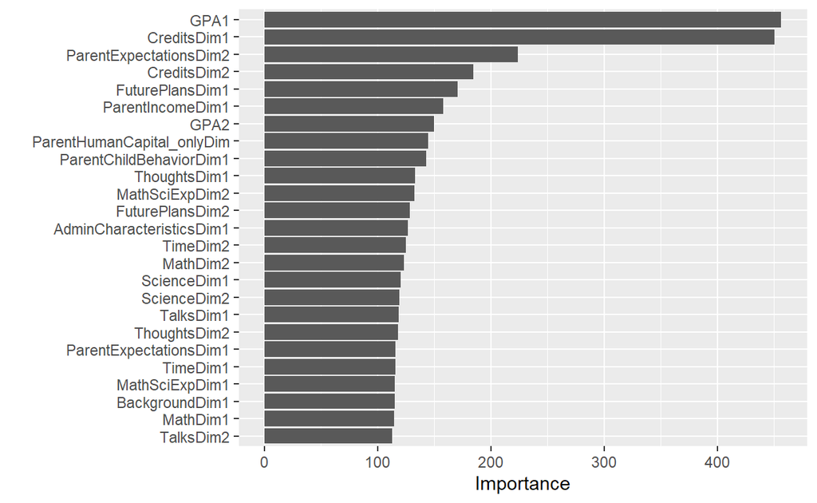

```r
#don't use imputed values for S3FOCUS... it is what we are trying to predict.
#instead, just use "blank"
mainDF <- mainDF %>% mutate_if(is.factor, fct_explicit_na, "blank")

#separate into training and test data...
set.seed(482405)
trn = sample(nrow(mainDF),19000)
trainingData <- mainDF[trn,]
testData <- mainDF[-trn,]

#now, use a random forest
rfImpurity <- ranger(formula = S3FOCUS ~ ., data = trainingData, num.trees = 700,
                     min.node.size = 1, sample.fraction = .80, replace = FALSE,
                     importance = "impurity", respect.unordered.factors = "order",
                     verbose = FALSE, seed  = 1392)

rfPermutation <- ranger(formula = S3FOCUS ~ ., data = trainingData, num.trees = 700,
                     min.node.size = 1, sample.fraction = .80, replace = FALSE,
                     importance = "permutation", respect.unordered.factors = "order",
                     verbose = FALSE, seed  = 1392)

#then graph
rfGraph1 <- vip::vip(rfImpurity, num_features = 25, bar = FALSE)
rfGraph2 <- vip::vip(rfPermutation, num_features = 25, bar = FALSE)

rfGraph1
```

In this graph we can see the top 25 MCA dimensions ordered in terms of impurity importance. It is important to note that these features come from across many of the surveys. This is an exciting finding as our previous work had just looked at the student survey. Creating the reduced dimension data frame has allowed us to glean new value from the HSLS:09 survey.

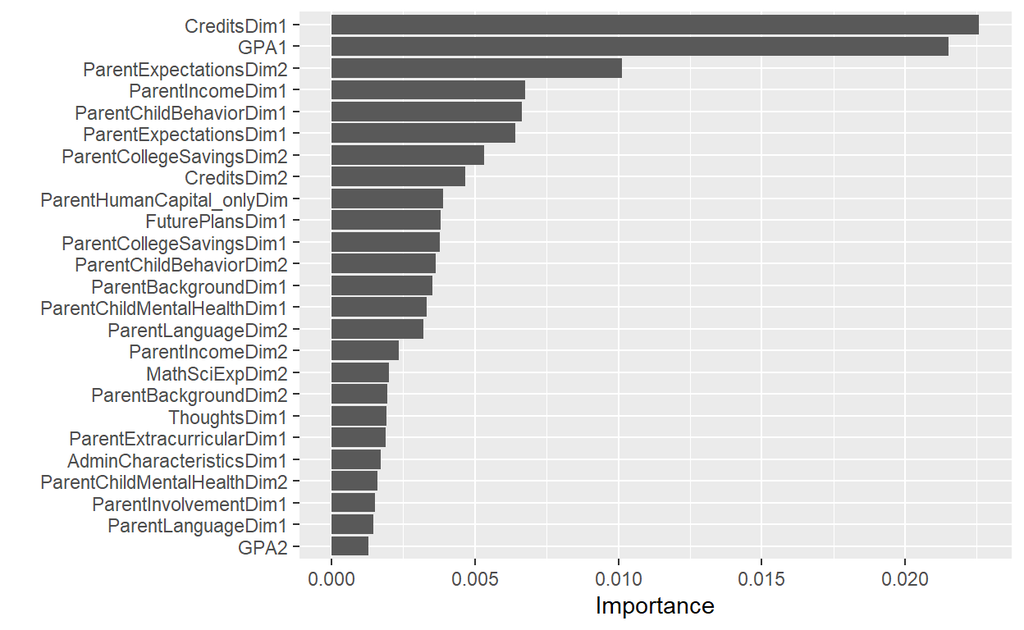

```r
rfGraph2
```

Finally, we calculate the RMSE to see how well our outcome is predicted. We present it below.

```r
predictedImpurity <- predict(rfImpurity, data=testData)$predictions
predictedImpurity <- as.numeric(as.factor(predictedImpurity))
actualImpurity <- as.numeric(testData$S3FOCUS)

rmseImpurity <- mean((predictedImpurity-actualImpurity)^2)^0.5

predictedPermutation <- predict(rfPermutation, data=testData)$predictions
predictedPermutation <- as.numeric(as.factor(predictedPermutation))
actualPermutation <- as.numeric(testData$S3FOCUS)

rmsePermutation <- mean((predictedPermutation-actualPermutation)^2)^0.5

rmseImpurity
```

```
[1] 3.972367
```

```r
rmsePermutation
```

```
[1] 3.972367
```

The RMSE is the same for both methods, as we would expect. Below we now try to predict college attendance post graduation since it was the most populare answer.

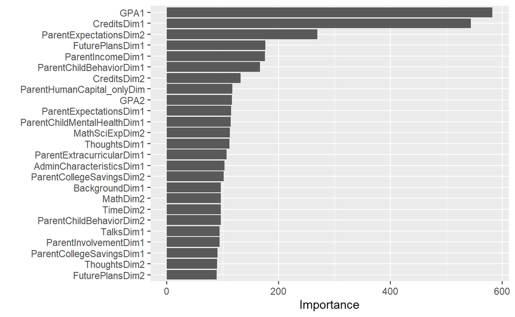

```r
#don't use imputed values for S3FOCUS... it is what we are trying to predict.
#instead, just use "blank"
collegeDF <- collegeDF %>% mutate_if(is.factor, fct_explicit_na, "blank")

#separate into training and test data...
set.seed(482405)
trn = sample(nrow(collegeDF),19000)
trainingDataCollege <- collegeDF[trn,]
testDataCollege <- collegeDF[-trn,]

#now, use a random forest
rfImpurityCollege <- ranger(formula = S3CLGFT ~ ., data = trainingDataCollege, num.trees = 700,
                     min.node.size = 1, sample.fraction = .80, replace = FALSE,
                     importance = "impurity", respect.unordered.factors = "order",
                     verbose = FALSE, seed  = 1392)

#then graph
rfGraphCollege <- vip::vip(rfImpurityCollege, num_features = 25, bar = FALSE)

rfGraphCollege
```

Compared to the impurity method with just general student outcomes, parent variables seem to be more important for attending college. Once again, GPA and credits matter the most. Future plans and child behavior become more important in predicting college attendance.

```r
predictedImpurityCollege <- predict(rfImpurityCollege, data=testDataCollege)$predictions
predictedImpurityCollege <- as.numeric(as.factor(predictedImpurityCollege))
actualImpurityCollege <- as.numeric(testData$S3CLGFT)

rmseImpurityCollege <- mean((predictedImpurityCollege-actualImpurityCollege)^2)^0.5

rmseImpurityCollege
```

```
[1] NaN
```

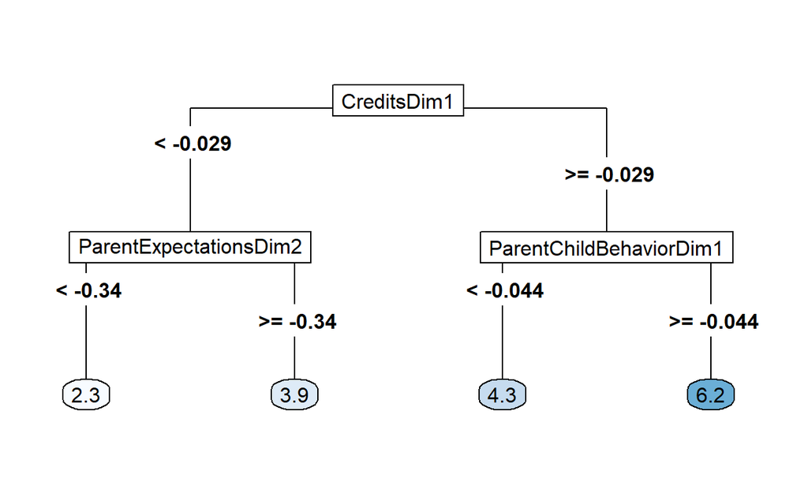

```r
regTree <- rpart(S3FOCUS ~ .,
                data=trainingData, method="anova")

prp(regTree, type = 5, branch = 1, varlen = 0, box.palette="Blues")
```

Just from this tree, we see credits, parent expectations, and child’s behavior (according to parents) being the main determinants for student outcomes.

```r
#get the RMSE
predictedTree <- predict(regTree, newdata = testData)
predictedTree <- as.numeric(as.factor(predictedTree))
actualTree <- as.numeric(testData$S3FOCUS)
rmseTree <- mean((predictedTree-actualTree)^2)^0.5
rmseTree
```

```
[1] 3.683546
```

Oddly, the tree has a lower RMSE. This could be happening because the hyperparameters on the random forest are not tuned well enough, or there is some other unknown underlying issue like being overfit on the training data. Either way, the regression tree is not interpretable.

Now, in reference back to our main questions presented on the first blog post, we want to make sure we have answered or discussed all aspects of our original question: “We are interested in studying the determinants of students’ post high school outcomes. We will begin by asking questions about which factors lead a student to pursue post-secondary education. Subsequently, we would like to better understand determinants that influence a student to attend a 2-year or technical college versus a traditional 4-year school. Are these decisions more related to individual characteristics or school fixed effects, or is there another underlying factor? How do student expectations compare to their actual outcomes?”

We did find in this blog post which factors contribute to pursuing a post-secondary education. We did not look into attending a two-year or four-year college, but that can be a future plan. We found that school fixed effects and teachers played a small role in influencing a child’s outcome, but parents and their expectations were highly influential. We found through previous blog posts that there is, in fact, a strong correlation between student expectations and actual outcomes.

Our future plan could be to map this to a structural model where teachers and schools serve as states, and the problem is from the perspective of a student or a parent, depending on how we want to frame this. It does seem that parents gain utility from their children attending college, which is a common mechanism found in macro education and macro family literature.